# Explore the dataset

## The study

This workshop will use CosMx Spatial Molecular Imager (SMI) data from the paper “Macrophage and neutrophil heterogeneity at single-cell spatial resolution in human inflammatory bowel disease” (Garrido-Trigo et al. 2023) - link: https://www.nature.com/articles/s41467-023-40156-6

There were 9x colon tissue samples, one per slide. They used a 1k RNA panel panel, (5k Xenium, 6k Cosmx and whole transcriptome kits are also out there).

- 3x Healthy controls (HC)
- 3x Crohn’s disease (CD)
- 3x Ulcerative colitis (UC)

For this workshop, we will work with a subsetted dataset;

- Only the Healthy and Crohn’s disease samples - 6x samples total
- Only a regional subset of each sample - first 4 ‘FOVs’ (Fields Of View - CosMx scan areas)

## The data object

This is a `SpatialFeatureExperiment` object. (Visit https://pachterlab.github.io/SpatialFeatureExperiment/articles/SFE.html for more information on this class.)

This subsetted dataset has 999 genes and 65601 cells.

```r
sfe
```

```
## class: SpatialFeatureExperiment
## dim: 999 65601
## metadata(0):
## assays(3): counts molecules logcounts
## rownames(999): AATK ABL1 ... NegPrb22 NegPrb23
## rowData names(3): target CodeClass hvg
## colnames(65601): HC_a_1000_1 HC_a_1000_2 ... CD_c_99_4 CD_c_9_2
## colData names(40): fov cell_ID ... clust_M0_lam0.6_k50_res0.3 niche
## reducedDimNames(2): PCA UMAP
## mainExpName: NULL
## altExpNames(0):
## spatialCoords names(2) : CenterX_global_px CenterY_global_px
## imgData names(4): sample_id image_id data scaleFactor
##
## unit: full_res_image_pixel
## Geometries:
## colGeometries: centroids (POINT), cellSeg (POLYGON)
##
## Graphs:
## GSM7473682_HC_a:
## GSM7473683_HC_b:
## GSM7473684_HC_c:
## GSM7473688_CD_a:
## GSM7473689_CD_b:
## GSM7473690_CD_c:
```

It has the following metadata for each cell.

```r
DT::datatable(as.data.frame(head(colData(sfe), n=300)))
```

|  | fov | cell_ID | Area | AspectRatio | CenterX_local_px | CenterY_local_px | Width | Height | Mean.MembraneStain | Max.MembraneStain | Mean.PanCK | Max.PanCK | Mean.CD45 | Max.CD45 | Mean.CD3 | Max.CD3 | Mean.DAPI | Max.DAPI | sample_id | slide_name | individual_code | tissue_sample | group | condition | fov_name | cell | total_count | distinct_genes | total_count_log10 | … |
| --- | --- | --- | --- | --- | --- | --- | --- | --- | --- | --- | --- | --- | --- | --- | --- | --- | --- | --- | --- | --- | --- | --- | --- | --- | --- | --- | --- | --- | --- | --- |
| HC_a_1000_1 | 1 | 1000_1 | 3946 | 0.59 | 2959 | 3232 | 58 | 99 | 752 | 4959 | 500 | 12951 | 329 | 23687 | 294 | 1235 | 15 | 87 | GSM7473682_HC_a | GSM7473682_HC_a | HC_a | HC_a | HC | Healthy controls | HC_a_001 | HC_a_1000_1 | 410 | 183 | 2.612783856719735 | … |
| HC_a_1000_2 | 2 | 1000_2 | 7218 | 1.4 | 4933 | 3004 | 118 | 84 | 1179 | 3083 | 20775 | 32601 | 428 | 1224 | 538 | 1925 | 23 | 139 | GSM7473682_HC_a | GSM7473682_HC_a | HC_a | HC_a | HC | Healthy controls | HC_a_002 | HC_a_1000_2 | 319 | 165 | 2.503790683057181 | … |
| HC_a_1000_4 | 4 | 1000_4 | 2833 | 1.14 | 2649 | 2215 | 75 | 66 | 1535 | 5316 | 528 | 1265 | 776 | 5342 | 537 | 1668 | 22 | 105 | GSM7473682_HC_a | GSM7473682_HC_a | HC_a | HC_a | HC | Healthy controls | HC_a_004 | HC_a_1000_4 | 439 | 221 | 2.642464520242121 | … |
| HC_a_1001_1 | 1 | 1001_1 | 6808 | 1.51 | 1170 | 3249 | 112 | 74 | 754 | 2279 | 784 | 20120 | 366 | 19202 | 206 | 1019 | 19 | 140 | GSM7473682_HC_a | GSM7473682_HC_a | HC_a | HC_a | HC | Healthy controls | HC_a_001 | HC_a_1001_1 | 229 | 136 | 2.359835482339888 | … |
| HC_a_1001_2 | 2 | 1001_2 | 3306 | 0.88 | 5408 | 2987 | 69 | 78 | 862 | 1586 | 14331 | 32572 | 335 | 893 | 455 | 1345 | 30 | 91 | GSM7473682_HC_a | GSM7473682_HC_a | HC_a | HC_a | HC | Healthy controls | HC_a_002 | HC_a_1001_2 | 115 | 78 | 2.060697840353612 | … |
| HC_a_1001_3 | 3 | 1001_3 | 4010 | 1.11 | 4238 | 1781 | 80 | 72 | 688 | 2852 | 493 | 3505 | 198 | 19073 | 252 | 1062 | 25 | 145 | GSM7473682_HC_a | GSM7473682_HC_a | HC_a | HC_a | HC | Healthy controls | HC_a_003 | HC_a_1001_3 | 242 | 132 | 2.383815365980431 | … |
| HC_a_1001_4 | 4 | 1001_4 | 1893 | 1.3 | 2907 | 2213 | 60 | 46 | 877 | 2932 | 407 | 2503 | 535 | 15843 | 409 | 1591 | 48 | 125 | GSM7473682_HC_a | GSM7473682_HC_a | HC_a | HC_a | HC | Healthy controls | HC_a_004 | HC_a_1001_4 | 282 | 164 | 2.450249108319361 | … |
| HC_a_1002_1 | 1 | 1002_1 | 3418 | 1.77 | 2141 | 3245 | 94 | 53 | 519 | 1921 | 238 | 1321 | 294 | 21188 | 235 | 1213 | 31 | 155 | GSM7473682_HC_a | GSM7473682_HC_a | HC_a | HC_a | HC | Healthy controls | HC_a_001 | HC_a_1002_1 | 227 | 142 | 2.356025857193123 | … |
| HC_a_1002_2 | 2 | 1002_2 | 2727 | 0.93 | 2826 | 3001 | 65 | 70 | 1788 | 3582 | 26380 | 32572 | 380 | 1405 | 394 | 1374 | 11 | 61 | GSM7473682_HC_a | GSM7473682_HC_a | HC_a | HC_a | HC | Healthy controls | HC_a_002 | HC_a_1002_2 | 198 | 116 | 2.296665190261531 | … |
| HC_a_1002_3 | 3 | 1002_3 | 2178 | 0.78 | 1499 | 1779 | 51 | 65 | 1210 | 3885 | 187 | 1952 | 59 | 901 | 393 | 6761 | 18 | 92 | GSM7473682_HC_a | GSM7473682_HC_a | HC_a | HC_a | HC | Healthy controls | HC_a_003 | HC_a_1002_3 | 86 | 49 | 1.934498451243568 | … |

[output cut: 290 more lines]

This was a ‘1k’ panel, we have 999 targets.

```r
DT::datatable(as.data.frame(rowData(sfe)))
```

|  | target | CodeClass | hvg |
| --- | --- | --- | --- |
| AATK | AATK | RNA | False |
| ABL1 | ABL1 | RNA | False |
| ABL2 | ABL2 | RNA | False |
| ACE | ACE | RNA | False |
| ACE2 | ACE2 | RNA | True |
| ACKR1 | ACKR1 | RNA | False |
| ACKR3 | ACKR3 | RNA | False |
| ACKR4 | ACKR4 | RNA | False |
| ACTA2 | ACTA2 | RNA | True |
| ACTG2 | ACTG2 | RNA | True |

[output cut: 989 more lines]

How many cells per sample?

```r
table(sfe$tissue_sample)
```

```
##
##  CD_a  CD_b  CD_c  HC_a  HC_b  HC_c
##  6723 13150 12929  8225 15642  8932
```

This data is subsetted to only 4 ‘Fields of View’ (FOV) per sample. On the CosMx platform, these are multiple rectangular regions that make up the run. Essentially we’re looking at a corner of each sample.

```r
#NB: ColData is a DataFrame, not a data.frame, often need an explicit conversion
colData(sfe) %>% as.data.frame() %>% select(group,tissue_sample, fov, fov_name) %>%
  group_by(group,tissue_sample, fov, fov_name) %>%
  summarise(n_cells = n())
```

```
## `summarise()` has regrouped the output.
## i Summaries were computed grouped by group, tissue_sample, fov, and fov_name.
## i Output is grouped by group, tissue_sample, and fov.
## i Use `summarise(.groups = "drop_last")` to silence this message.
## i Use `summarise(.by = c(group, tissue_sample, fov, fov_name))` for
##   per-operation grouping (`?dplyr::dplyr_by`) instead.
```

| group | tissue_sample | fov | fov_name | n_cells |
| --- | --- | --- | --- | --- |
| HC | HC_a | 1 | HC_a_001 | 2555 |
| HC | HC_a | 2 | HC_a_002 | 2001 |
| HC | HC_a | 3 | HC_a_003 | 1225 |
| HC | HC_a | 4 | HC_a_004 | 2444 |
| HC | HC_b | 1 | HC_b_001 | 4519 |
| HC | HC_b | 2 | HC_b_002 | 3729 |
| HC | HC_b | 3 | HC_b_003 | 3344 |
| HC | HC_b | 4 | HC_b_004 | 4050 |
| HC | HC_c | 1 | HC_c_001 | 1082 |
| HC | HC_c | 2 | HC_c_002 | 2837 |

[output cut: 13 more lines]

## The existing annotation

We’ll be using 5 broad cell types. These are from Garrido-Trigo et al’s original paper.

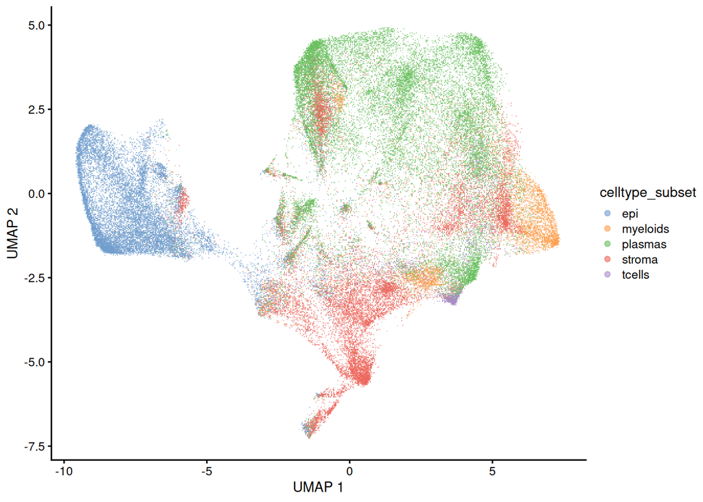

```r
plotUMAP(sfe, colour_by='celltype_subset', scattermore=1)
```

Lets check them out on the actual tissue, one of the healthy control samples.

A note on the tissue morphology: Here the top would be the lumen of the colon, and a stromal layer at the bottom known as the lamina propria. The oval-shaped epithelial structures are crypts. See: https://www.pathologyoutlines.com/topic/colonhistology.html

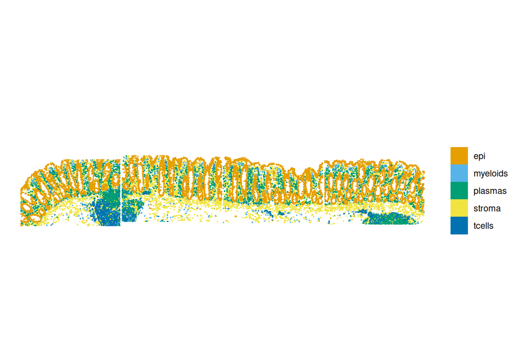

```r
plotSpatialFeature(sfe.sample.HC, 'celltype_subset', colGeometryName = "cellSeg") +
  theme(legend.title=element_blank()) +
  ggtitle(sample)
```

There are multiple levels of cell type annotation in this dataset.

There is the very (very) detailed `celltype_singleR2`, used for various analyses in the original paper;

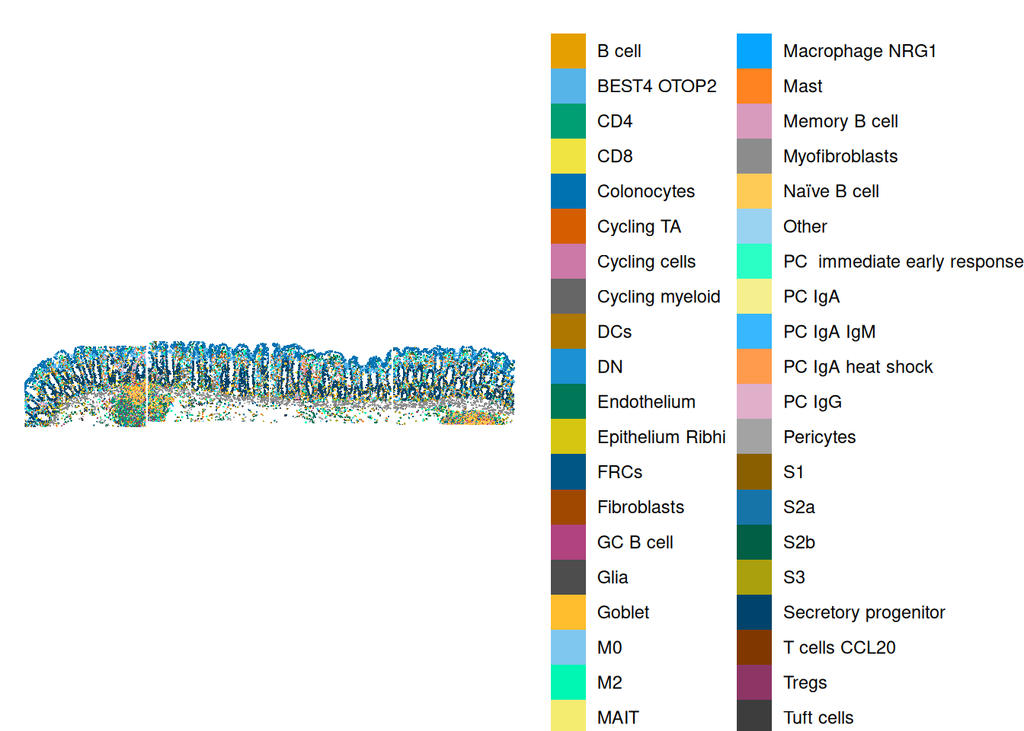

```r
# Remove cell types with less than 30 instances, purely for plotting.
cell_counts <- table(sfe.sample.HC$celltype_SingleR2)
sfe.sample.HC$filtered_celltype_singleR2 <- as.character(ifelse(cell_counts[as.character(sfe.sample.HC$celltype_SingleR2)] >= 30 , as.character(sfe.sample.HC$celltype_SingleR2), "Other"))

plotSpatialFeature(sfe.sample.HC, 'filtered_celltype_singleR2', colGeometryName = "cellSeg") +
  theme(legend.title=element_blank()) +
  ggtitle(sample)
```

And some unlabelled clusters generated purely on transcriptional similarity. These might represent a nice level of classification if were were doing the analysis from scratch.

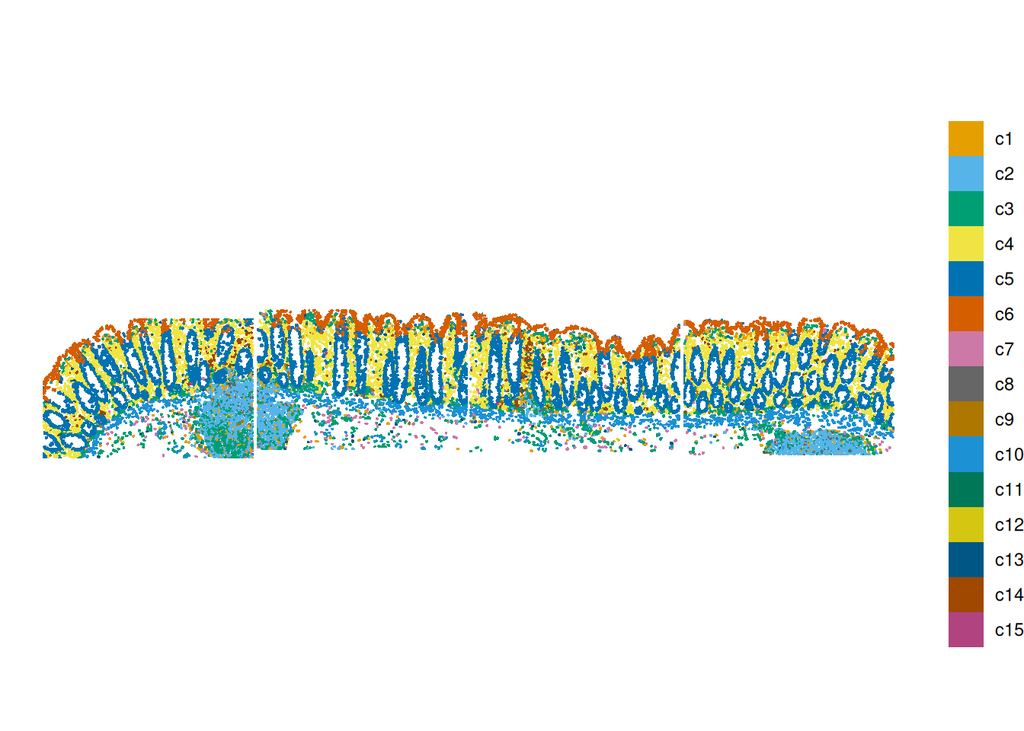

```r
plotSpatialFeature(sfe.sample.HC, 'cluster_code', colGeometryName = "cellSeg") +
  theme(legend.title=element_blank()) +
  ggtitle(sample)
```

Of course, we can plot any gene’s expression (so long as its present on the 1k panel!)

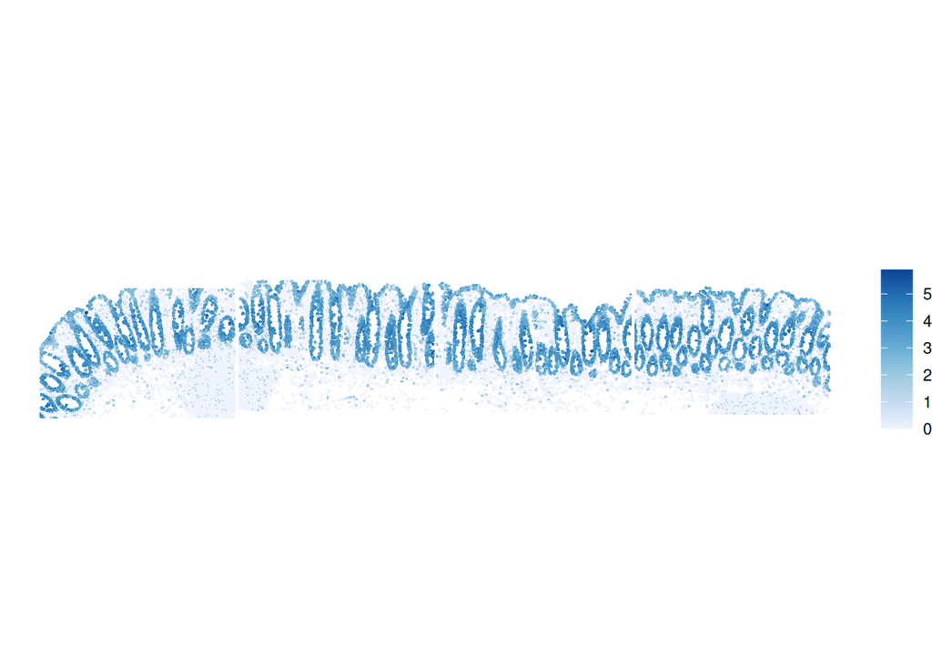

```r
plotSpatialFeature(sfe.sample.HC, 'PIGR', colGeometryName = "cellSeg") +
  theme(legend.title=element_blank()) +
  ggtitle(sample)
```